# Machine Learning with Coursera

Jae Kwan Koo

# Nueral Networks Representation

## Model representation 1

신경망은 뇌속의 뉴런이나 뉴런의 연결망처럼 보이게 만들어 졌다.  
가설 표현을 설명하기 위해서 뇌속의 단일 뉴런을 살펴보자.

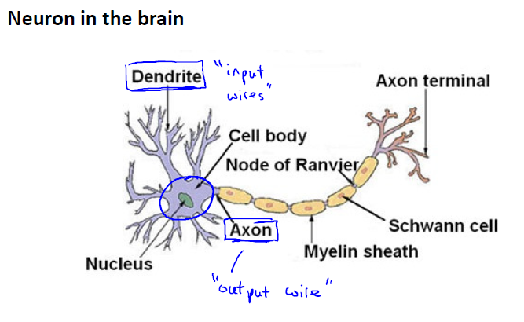

`수상돌기(dendrite)` : 다른 위치의 뉴런으로부터 입력을 받는 입력단자  
`축삭돌기(Axon)` : 다른 뉴런으로 신호를 전달하고 메시지를 전달하는 출력단자

뉴런은 계산 단위이고, 여러개의 입력 단자로부터 값을 받아 특정 계산을 수행하고 축삭돌기를 통해 출력값을 다른 노드나 뉴런으로 보낸다.

결국 한 뉴런에서 다른 세포로 신호를 전달하게 되는데, 서로 다른 뉴런과 뉴런 사이에는 시냅스(Synapse)라는 틈이 존재한다.  
이 틈을 통해 신경전달물질이 이동해서 뉴런간의 신호를 보낼 수 있다.

예컨대, 작은 전기 펄스를 축삭돌기를 통해서 다른 뉴런에게 보내고, 축삭돌기는 다른 뉴런의 수상돌기에 연결되어 메시지를 받아서 특정 계산을 수행한다.  
그리고 다른 뉴런에게 이 출삭돌기를 통해 메시지를 다시 보낸다.  
계산을 수행하여 다른 뉴런에게 메시지를 전달하고 그 결과 다른 뉴런의 입력단자는 그 메시지를 받는 형태인 것이다.

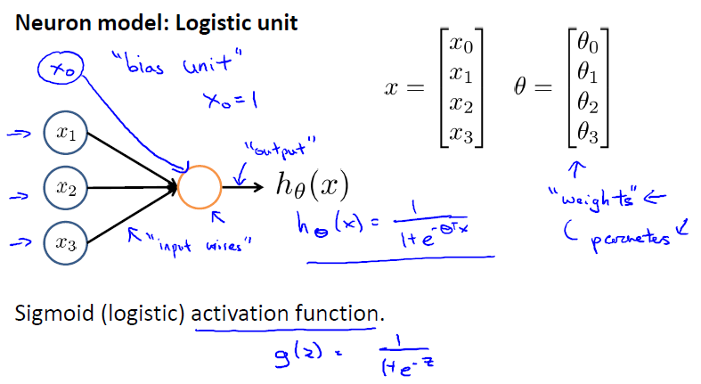

- 모델로 사용할 뉴런은 단지 논리적인 단위
- 노란 원 : 하나의 뉴런
- x,y : parameter vector
- $x_0$ : bias 뉴런, bias unit - $x_0=1$, 가독성을 위해 생략하기도 한다.
- $\theta$ : 모델의 가중치(witghts), 보통 W라고 표현

$$Sigmoid(logistic)\, activation\,function : g(z)\,=\,{1\over1+e^{-z}}$$

[What is the role of the bias in neural networks?](https://stackoverflow.com/questions/2480650/what-is-the-role-of-the-bias-in-neural-networks)

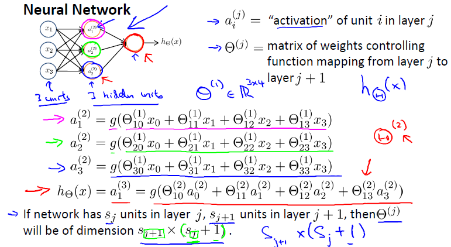

인공신경망은 여러개의 뉴런 그룹들이 연결된 것

- 입력 유닛 x1, x2, x3 / x0은 추가해도 되고 안해도 된다.
- $a_0=1$ : bias unit

마지막 레이어에 있는 이 노드는 가설 h(x)을 계산한 값을 출력합니다.

- Input layer : 이 곳에서 feature x1, x2, x3 를 입력받기 때문
- Hidden layer : supervised learning에서 training set에 있는 인풋과 아웃풋은 볼 수 있지만 히든 레이어에 있는 값들은 training set에서 볼 수가 없기 때문에 x도 y도 아니기 때문에 히든이라 부름
- Output layer : 하나의 뉴런을 갖고 있는데 이 뉴런이 가설(hypothesis)을 계산한 최종 값을 출력하기 때문

이 예제에는 각각 1개의 input layer, hidden layer, output layer 총 3개 layer가 있다.  
기본적으로 input layer, output layer가 아닌 것들은 hidden layer이다.

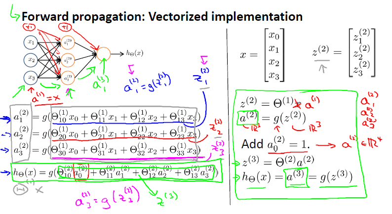

$a_1^{(2)}$ : layer2 (hidden layer)에서의 첫번째 unit의 activation  
`activation` : unit에서 계산된 output value

인공신경망은 매트릭스들로 표현된다.  
$\theta(j)$ : 한 레이어를 다른 레이어로 매핑하는 함수를 조절하는 가중치의 매트릭스

신경망의 j번째 레이어에 $s_j$개 유닛이 있고 j+1번째 레이어에 $s_{j+1}$개 유닛이 있는 경우  
레이어 j에서 j+1로 매핑하는 $θ^{(j)}$ 행렬의 dimension $s_{j+1}$x($s_j$+1)차원 행렬이 된다.

if layer 1 has 2 input nodes and layer 2 has 4 activation nodes, Dimension of $\theta^{(1)}$ is going to be 4x3 where $s_j=2$ and $s_{j+1}=4$, so $s_{j+1}$x($s_j+1$)=4x3

$θ^{(2)}$는 파라미터들의 행렬 또는 두번째 레이어 유닛들을 세번째 레이어, 즉 아웃풋 레이어 유닛으로 매핑하는 가중치의 행렬이다.

인공신경망은 함수 h를 정의하는 것인데, 함수 h는 x를 입력받아 y를 예측하는 함수입니다 그리고 이 가설(hypothesis)은 파라미터들에 의해 조절되는데 파라미터들은 대문자 $\theta$로 표기하고, 우리가 $\theta$를 변화시킨다면 가설(hypothesis) 또한 달라지고, x에서 y로 매핑하는 함수 또한 달라지게 됩니다.

그럼 어떻게 $\theta$를 정의할 것인지 알아보자

## Model representaion 2

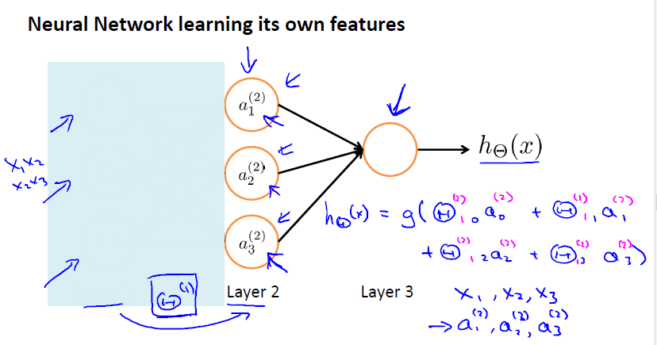

sigmoid 함수안의 인자들을 z라고 표현하자.  
이 z values들은 단지 x0, x1, x2, x3와 가중치들간의 선형 결합이다.

이 과정을 forward propagation이라고 부른다.  
왜냐하면 우리는 input unit의 활성에서 시작하고 그 다음, hidden layer에 전진 전파를 하고 hidden layer의 활성을 계산한다음 다시 앞으로 전파아여 output layer의 활성을 계산하기 때문이다. input, hidden 그 다음 output layer으로부터의 활성을 계산하는 과정이다.

이 forward propagation 장면 역시 우리가 neural networks가 하는 일이 어떤 것인지, 왜 그것들이 우리가 non-linear hypotheses를 흥미롭게 배울 수 있게 하는지 이해하도록 도와준다.

왼편의 그림을 가리고 생각을 해보자. 이제 이 그림은 로지스틱 회귀처럼 보인다.  
g는 sigmoid activation function이고, 여기서 a0=1이다.

## Examples and intuitions 1

### AND

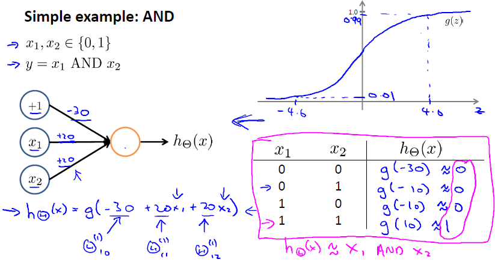

가중치를 다음과 같이 선택하면 x1 and x2의 형태로 h가 나오도록 할 수 있다.

### OR

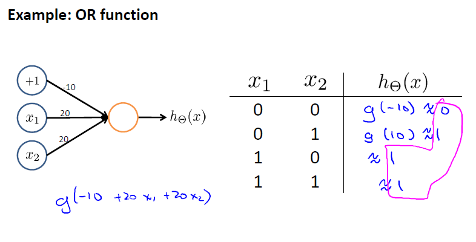

이것도 계산해보면 or이라는 것을 알 수 있다.

## Examples and intuitions 2

### Negate

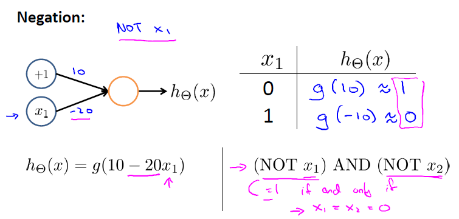

반대로 나오는 식도 만들어볼 수 있다.

만약 x1과 x2둘다 아니라는 식을 만들고 싶으면 x1=x2=0이 되는 것이나 같은 말이다.

$\theta=[10,-20,-20]^T$일 때, (NOT x1) AND (NOT x2)를 만족하게 된다.

### Put it together - XNOR

XOR, XNOR은 배타적 논리합, 배타적 부정 논리합이다.

XOR : 2개의 입력이 서로 같으면 출력은 0, 다르면 1이다.

| A | B | X |
| --- | --- | --- |
| 0 | 0 | 0 |
| 0 | 1 | 1 |
| 1 | 0 | 1 |
| 1 | 1 | 0 |

XNOR : 2개의 입력이 서로 같으면 출력은 1, 다르면 0이다. XOR에 NOT을 붙인 것과 같다.

| A | B | X |
| --- | --- | --- |
| 0 | 0 | 1 |
| 0 | 1 | 0 |
| 1 | 0 | 0 |
| 1 | 1 | 1 |

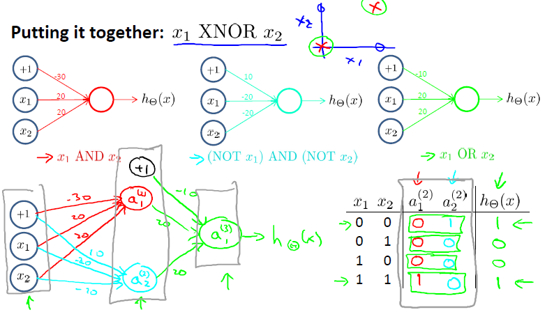

AND를 나타내는 것이 $a_1^{(2)}$이고, (NOT x1) AND (NOT x2)를 나타내는 것이 $a_2^{(2)}$이므로 쉽게 계산가능하다. 또한, 가설 h는 or에 의해 얻어진다.

## Multi-class classification

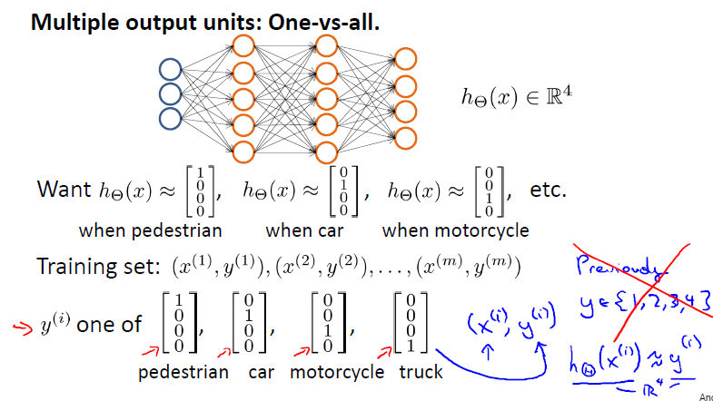

신경망을 이용해서 하기 위해서는 one vs all의 확장된 방법을 이용해야 한다.

차인지 인식하는 것 뿐만 아니라, 차를 4가지로 분류하고 싶은 것이다.  
이렇게 분류하기 위해서는 신경망을 구성할 때 출력 레이어에 4개의 유닛을 넣도록 구성하면 된다.

보행자 분류된 경우 output : [1 0 0 0]  
자동차 : [0 1 0 0]  
오토바이 : [0 0 1 0]  
트럭 : [0 0 0 1]

one vs all에 대한 로지스틱 회귀와 같다. 여기에 4개의 로지스틱 회귀 classifier들이 있고 각각은 4개의 분류중 하나씩을 나타내게 된다.  
예전에는 우리가 사진에 대한 label을 1, 2, 3, 4와 같은 숫자로 붙였다면 이제는 이미지 $X_i$에 대한 결과를 숫자로 된 라벨 대신 [1, 0, 0, 0], [0, 1, 0, 0], [0, 0, 1, 0], [0, 0, 0, 1]과 같이 표현하고 $Y_i$라고 할 것 이다.  
결과적으로 하나의 예제는 ($X_i$ , $Y_i$) 쌍이 될 것

- Xi는 4가지 분류 중 하나인 이미지
- Yi는 해당 이미지의 분류를 나타내는 벡터

## Practice

```r
CostFunction <- function(X, y, Theta, Lambda){
  m <- length(y)
  Hypothesis <- 1 / (1 + exp(- X %*% Theta)) # probability that y = 1 on input X
  J <- (1/m) * sum(- y * log(Hypothesis) - (1 - y) * log(1 - Hypothesis)) # compute J cost
  reg <- (Lambda / (2 * m)) * sum(Theta[2:length(Theta)] ^ 2)
  J <- J + reg
  return(J)
}


GradFunction <- function(X, y, Theta, Lambda){
  m <- length(y)
  Hypothesis <- 1 / (1 + exp(- X %*% Theta))
  Grad <- ((t(X) %*% (Hypothesis - y)) / m) + ((Lambda / m) * c(0,Theta[2:length(Theta)]))
  return(Grad)
}
```

```r
library(R.matlab)
ds_data <- readMat("ex3data1.mat")
ds_weight <- readMat("ex3weights.mat")

X <- as.matrix(ds_data$X)
X <- cbind(1, X)
y <- as.vector(ds_data$y)

theta1 <- as.matrix(ds_weight$Theta1)
theta2 <- as.matrix(ds_weight$Theta2)
```

```r
theta_t <- c(-2, -1, 1, 2)
X_t <- as.matrix(cbind(1, matrix(1:15, 5,3)/10))
y_t <- c(1, 0, 1, 0, 1) >= 0.5
lambda_t <- 3




CostFunction(X_t, y_t, theta_t, lambda_t)
```

```
## [1] 2.534819
```

```r
GradFunction(X_t, y_t, theta_t, lambda_t)
```

```
##            [,1]
## [1,]  0.1465614
## [2,] -0.5485584
## [3,]  0.7247223
## [4,]  1.3980030
```

```r
# Train Logistic Regression
TrainLogisticReg <- function(X, y, Lambda){
  ifelse(is.vector(X), initial_theta <- c(0,0), initial_theta <- rep(0, ncol(X))) # initialize theta
  ifelse(is.vector(X), m <- length(X), m <- nrow(X))

  assign("m", m, .GlobalEnv)

  LogisticRec <- optim(par = initial_theta,
                       fn = CostFunction,
                       gr = GradFunction,
                       method = "BFGS",
                       X = X,
                       y = y,
                       Lambda = Lambda)

  print(paste("J", LogisticRec$value))
  return(LogisticRec$par)
}

theta_result <- TrainLogisticReg(X, y, 0)
```

```
## [1] "J -78.1116869389638"
```

```r
# One vs All function
# note that we already had 1 to X
OneVsAllFunction <- function(X, y, Lambda){

  y_cat <- unique(y) # determine how many categories we have within y
  Predict_result <- matrix(nrow = nrow(X), ncol = length(y_cat)) # create a matrix to put the Y prediction
  colnames(Predict_result) <- y_cat # put the category names

  Theta_result <- matrix(nrow = length(y_cat), ncol = ncol(X)) # +1 for theta 0 already counted

  row.names(Theta_result) <- y_cat

  for(i in 1:length(y_cat)){
    y_temp <- rep(0, length(y))

    for(j in 1:length(y)){ #loop to create the 1 | 0  y_temp
      ifelse(y[j] == y_cat[i], y_temp[j] <- 1, y_temp[j] <- 0)
    }

    Theta_temp <- TrainLogisticReg(X, y_temp, Lambda)
    Predict_result[ ,i] <- 1 / (1 + exp(- X %*% Theta_temp)) #probability that y = 1 on input X
    Theta_result[i, ] <- Theta_temp

  }

  Predict_result <- as.data.frame(Predict_result)
  # check which column has the max result
  Predict_result$Final <- max.col(Predict_result[ ,1:length(y_cat)], ties.method = "first")
  for (k in 1 : m){
    a <- Predict_result$Final[k]
    Predict_result$Final[k] <- colnames(Predict_result)[as.numeric(a)]

  }

  Result <- list("Predict" = Predict_result, "Theta" = Theta_result) # create list of the result
  return(Result)

}


lambda <- 0.1
test <- OneVsAllFunction(X, y, lambda)
```

```
## [1] "J 0.0103494707209181"
## [1] "J 0.0148622440173195"
## [1] "J 0.0567794334766962"
## [1] "J 0.0629846884235192"
## [1] "J 0.0381953746039654"
## [1] "J 0.0614150237069662"
## [1] "J 0.0221935890719235"
## [1] "J 0.0349697783660666"
## [1] "J 0.0833928138934852"
## [1] "J 0.0770231714049791"
```

```r
table(test$Predict$Final, y)
```

```
##     y
##        1   2   3   4   5   6   7   8   9  10
##   1  496   2   2   1   1   0   1   4   1   0
##   10   0   2   0   0   2   2   0   0   2 496
##   2    1 466  11   1   3   0   2   3   3   0
##   3    0   3 459   0  12   0   1   9   4   1
##   4    1   4   1 481   4   1   4   7   7   1
##   5    1   3  11   0 458   4   1   4   3   1
##   6    0   3   1   1   4 492   0   4   1   0
##   7    0   3   6   0   1   0 480   2  12   0
##   8    1  11   3   4   9   1   1 461   4   1
##   9    0   3   6  12   6   0  10   6 463   0
```

```r
mean(test$Predict$Final == y)
```

```
## [1] 0.9504
```

```r
##

#PREDICT Predict the label of an input given a trained neural network
#%   p = PREDICT(Theta1, Theta2, X) outputs the predicted label of X given the
#%   trained weights of a neural network (Theta1, Theta2)
Theta1 <- ds_weight$Theta1
Theta2 <- ds_weight$Theta2

predict <- function(Theta1, Theta2, X){
  # Useful values
  ifelse(is.vector(X), m <- length(X), m <- nrow(X))
  p <- rep(0, nrow(X))

  # the +1 on X are already taken into account
  A1 <- 1 / (1 + exp(- X %*% t(Theta1)))
  A1 <- cbind(1, A1)
  A2 <- 1 / (1 + exp(- A1 %*% t(Theta2)))
  p <- apply(A2, 1, FUN= "which.max")
  return(p)
}


pred <- predict(Theta1, Theta2, X)


print(mean(pred == y))
```

```
## [1] 0.9752
```

## Refer

[R 실습 코드](http://rstudio-pubs-static.s3.amazonaws.com/339822_0b37bdc0fc9f4317bfd38b697aace71b.html)